# Risk Factor Analysis

## Outcome Variable

**Outcome Variable:** stunted

## Predictor Variables

**Intervention Variable:** fhtcm

**Adjustment Set:**

- arm
- W_mage
- W_fage
- meducyrs
- feducyrs
- W_mhtcm
- W_mwtkg
- W_mbmi
- single
- delta_W_mage
- delta_W_fage
- delta_meducyrs
- delta_feducyrs
- delta_W_mhtcm
- delta_W_mwtkg
- delta_W_mbmi
- delta_single

## Stratifying Variables

The analysis was stratified on these variable(s):

- agecat
- studyid
- country

## Data Summary

| agecat | studyid | country | fhtcm | stunted | n_cell | n |
| --- | --- | --- | --- | --- | --- | --- |
| Birth | ki1000304b-SAS-CompFeed | INDIA | >=167 cm | 0 | 38 | 102 |
| Birth | ki1000304b-SAS-CompFeed | INDIA | >=167 cm | 1 | 12 | 102 |
| Birth | ki1000304b-SAS-CompFeed | INDIA | <162 cm | 0 | 17 | 102 |
| Birth | ki1000304b-SAS-CompFeed | INDIA | <162 cm | 1 | 6 | 102 |
| Birth | ki1000304b-SAS-CompFeed | INDIA | [162-167) cm | 0 | 20 | 102 |
| Birth | ki1000304b-SAS-CompFeed | INDIA | [162-167) cm | 1 | 9 | 102 |
| Birth | ki1101329-Keneba | GAMBIA | >=167 cm | 0 | 735 | 1165 |
| Birth | ki1101329-Keneba | GAMBIA | >=167 cm | 1 | 37 | 1165 |
| Birth | ki1101329-Keneba | GAMBIA | <162 cm | 0 | 82 | 1165 |
| Birth | ki1101329-Keneba | GAMBIA | <162 cm | 1 | 5 | 1165 |
| Birth | ki1101329-Keneba | GAMBIA | [162-167) cm | 0 | 290 | 1165 |
| Birth | ki1101329-Keneba | GAMBIA | [162-167) cm | 1 | 16 | 1165 |
| Birth | ki1119695-PROBIT | BELARUS | >=167 cm | 0 | 11714 | 12533 |
| Birth | ki1119695-PROBIT | BELARUS | >=167 cm | 1 | 26 | 12533 |
| Birth | ki1119695-PROBIT | BELARUS | <162 cm | 0 | 168 | 12533 |
| Birth | ki1119695-PROBIT | BELARUS | <162 cm | 1 | 0 | 12533 |
| Birth | ki1119695-PROBIT | BELARUS | [162-167) cm | 0 | 622 | 12533 |
| Birth | ki1119695-PROBIT | BELARUS | [162-167) cm | 1 | 3 | 12533 |
| Birth | ki1135781-COHORTS | GUATEMALA | >=167 cm | 0 | 26 | 206 |
| Birth | ki1135781-COHORTS | GUATEMALA | >=167 cm | 1 | 3 | 206 |
| Birth | ki1135781-COHORTS | GUATEMALA | <162 cm | 0 | 111 | 206 |
| Birth | ki1135781-COHORTS | GUATEMALA | <162 cm | 1 | 10 | 206 |
| Birth | ki1135781-COHORTS | GUATEMALA | [162-167) cm | 0 | 54 | 206 |
| Birth | ki1135781-COHORTS | GUATEMALA | [162-167) cm | 1 | 2 | 206 |
| 6 months | ki1000304b-SAS-CompFeed | INDIA | >=167 cm | 0 | 281 | 807 |
| 6 months | ki1000304b-SAS-CompFeed | INDIA | >=167 cm | 1 | 88 | 807 |
| 6 months | ki1000304b-SAS-CompFeed | INDIA | <162 cm | 0 | 129 | 807 |
| 6 months | ki1000304b-SAS-CompFeed | INDIA | <162 cm | 1 | 65 | 807 |
| 6 months | ki1000304b-SAS-CompFeed | INDIA | [162-167) cm | 0 | 168 | 807 |
| 6 months | ki1000304b-SAS-CompFeed | INDIA | [162-167) cm | 1 | 76 | 807 |
| 6 months | ki1000304b-SAS-FoodSuppl | INDIA | >=167 cm | 0 | 64 | 372 |
| 6 months | ki1000304b-SAS-FoodSuppl | INDIA | >=167 cm | 1 | 38 | 372 |
| 6 months | ki1000304b-SAS-FoodSuppl | INDIA | <162 cm | 0 | 72 | 372 |
| 6 months | ki1000304b-SAS-FoodSuppl | INDIA | <162 cm | 1 | 76 | 372 |
| 6 months | ki1000304b-SAS-FoodSuppl | INDIA | [162-167) cm | 0 | 77 | 372 |
| 6 months | ki1000304b-SAS-FoodSuppl | INDIA | [162-167) cm | 1 | 45 | 372 |
| 6 months | ki1101329-Keneba | GAMBIA | >=167 cm | 0 | 849 | 1511 |
| 6 months | ki1101329-Keneba | GAMBIA | >=167 cm | 1 | 130 | 1511 |
| 6 months | ki1101329-Keneba | GAMBIA | <162 cm | 0 | 98 | 1511 |
| 6 months | ki1101329-Keneba | GAMBIA | <162 cm | 1 | 15 | 1511 |
| 6 months | ki1101329-Keneba | GAMBIA | [162-167) cm | 0 | 355 | 1511 |
| 6 months | ki1101329-Keneba | GAMBIA | [162-167) cm | 1 | 64 | 1511 |
| 6 months | ki1119695-PROBIT | BELARUS | >=167 cm | 0 | 10535 | 11895 |
| 6 months | ki1119695-PROBIT | BELARUS | >=167 cm | 1 | 611 | 11895 |
| 6 months | ki1119695-PROBIT | BELARUS | <162 cm | 0 | 131 | 11895 |
| 6 months | ki1119695-PROBIT | BELARUS | <162 cm | 1 | 25 | 11895 |
| 6 months | ki1119695-PROBIT | BELARUS | [162-167) cm | 0 | 529 | 11895 |
| 6 months | ki1119695-PROBIT | BELARUS | [162-167) cm | 1 | 64 | 11895 |
| 6 months | ki1135781-COHORTS | GUATEMALA | >=167 cm | 0 | 31 | 336 |
| 6 months | ki1135781-COHORTS | GUATEMALA | >=167 cm | 1 | 14 | 336 |
| 6 months | ki1135781-COHORTS | GUATEMALA | <162 cm | 0 | 88 | 336 |
| 6 months | ki1135781-COHORTS | GUATEMALA | <162 cm | 1 | 109 | 336 |
| 6 months | ki1135781-COHORTS | GUATEMALA | [162-167) cm | 0 | 61 | 336 |
| 6 months | ki1135781-COHORTS | GUATEMALA | [162-167) cm | 1 | 33 | 336 |
| 24 months | ki1101329-Keneba | GAMBIA | >=167 cm | 0 | 569 | 1297 |
| 24 months | ki1101329-Keneba | GAMBIA | >=167 cm | 1 | 252 | 1297 |
| 24 months | ki1101329-Keneba | GAMBIA | <162 cm | 0 | 63 | 1297 |
| 24 months | ki1101329-Keneba | GAMBIA | <162 cm | 1 | 34 | 1297 |
| 24 months | ki1101329-Keneba | GAMBIA | [162-167) cm | 0 | 216 | 1297 |
| 24 months | ki1101329-Keneba | GAMBIA | [162-167) cm | 1 | 163 | 1297 |
| 24 months | ki1119695-PROBIT | BELARUS | >=167 cm | 0 | 3161 | 3670 |
| 24 months | ki1119695-PROBIT | BELARUS | >=167 cm | 1 | 284 | 3670 |
| 24 months | ki1119695-PROBIT | BELARUS | <162 cm | 0 | 42 | 3670 |
| 24 months | ki1119695-PROBIT | BELARUS | <162 cm | 1 | 11 | 3670 |
| 24 months | ki1119695-PROBIT | BELARUS | [162-167) cm | 0 | 149 | 3670 |
| 24 months | ki1119695-PROBIT | BELARUS | [162-167) cm | 1 | 23 | 3670 |
| 24 months | ki1135781-COHORTS | GUATEMALA | >=167 cm | 0 | 25 | 528 |
| 24 months | ki1135781-COHORTS | GUATEMALA | >=167 cm | 1 | 47 | 528 |
| 24 months | ki1135781-COHORTS | GUATEMALA | <162 cm | 0 | 53 | 528 |
| 24 months | ki1135781-COHORTS | GUATEMALA | <162 cm | 1 | 254 | 528 |
| 24 months | ki1135781-COHORTS | GUATEMALA | [162-167) cm | 0 | 40 | 528 |
| 24 months | ki1135781-COHORTS | GUATEMALA | [162-167) cm | 1 | 109 | 528 |

The following strata were considered:

- agecat: 24 months, studyid: ki1101329-Keneba, country: GAMBIA
- agecat: 24 months, studyid: ki1119695-PROBIT, country: BELARUS
- agecat: 24 months, studyid: ki1135781-COHORTS, country: GUATEMALA
- agecat: 6 months, studyid: ki1000304b-SAS-CompFeed, country: INDIA
- agecat: 6 months, studyid: ki1000304b-SAS-FoodSuppl, country: INDIA
- agecat: 6 months, studyid: ki1101329-Keneba, country: GAMBIA
- agecat: 6 months, studyid: ki1119695-PROBIT, country: BELARUS
- agecat: 6 months, studyid: ki1135781-COHORTS, country: GUATEMALA
- agecat: Birth, studyid: ki1000304b-SAS-CompFeed, country: INDIA
- agecat: Birth, studyid: ki1101329-Keneba, country: GAMBIA
- agecat: Birth, studyid: ki1119695-PROBIT, country: BELARUS
- agecat: Birth, studyid: ki1135781-COHORTS, country: GUATEMALA

### Dropped Strata

Some strata were dropped due to rare outcomes:

- agecat: Birth, studyid: ki1119695-PROBIT, country: BELARUS
- agecat: Birth, studyid: ki1135781-COHORTS, country: GUATEMALA

## Methods Detail

We’re interested in the causal parameters $E[Y_a]$ for all values of $a \in \mathcal{A}$. These parameters represent the mean outcome if, possibly contrary to fact, we intervened to set all units to have $A=a$. Under the randomization and positivity assumptions, these are identified by the statistical parameters $\psi_a=E_W[E_{Y|A,W}(Y|A=a,W)]$. In addition, we’re interested in the mean of $Y$, $E[Y]$ under no intervention (the observed mean). We will estimate these parameters by using SuperLearner to fit the relevant likelihood factors – $E_{Y|A,W}(Y|A=a,W)$ and $p(A=a|W)$, and then updating our likelihood fit using a joint TMLE.

For unadjusted analyses ($W=\{\}$), initial likelihoods were estimated using Lrnr_glm to estimate the simple $E(Y|A)$ and Lrnr_mean to estimate $p(A)$. For adjusted analyses, a small library containing Lrnr_glmnet, Lrnr_xgboost, and Lrnr_mean was used.

Having estimated these parameters, we will then use the delta method to estimate relative risks and attributable risks relative to a prespecified baseline level of $A$.

# Results Detail

## Results Plots

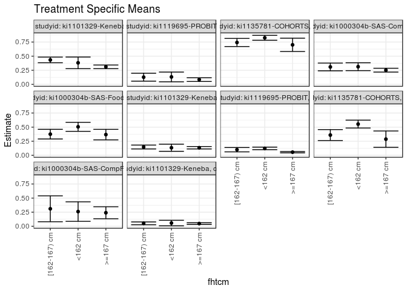

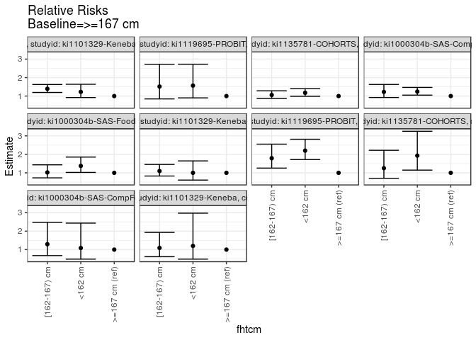

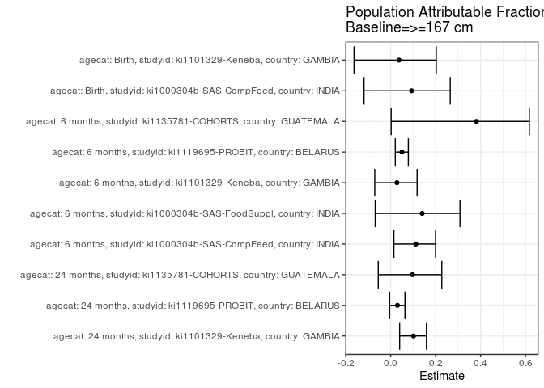

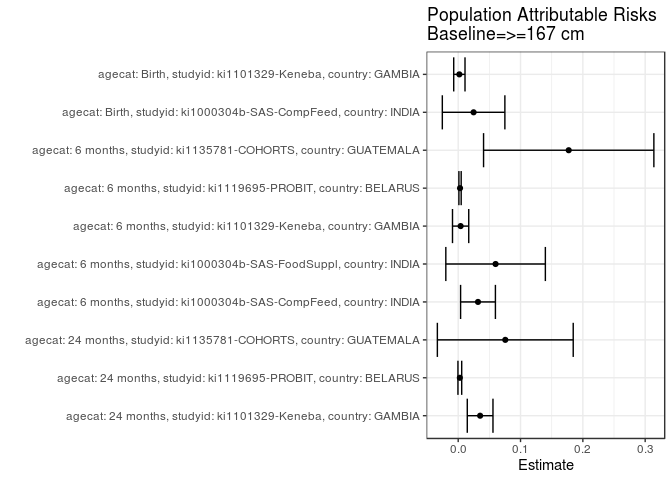

## Results Table

### Parameter: TSM

| agecat | studyid | country | intervention_level | baseline_level | estimate | ci_lower | ci_upper |
| --- | --- | --- | --- | --- | --- | --- | --- |
| Birth | ki1000304b-SAS-CompFeed | INDIA | >=167 cm | NA | 0.2400000 | 0.1335281 | 0.3464719 |
| Birth | ki1000304b-SAS-CompFeed | INDIA | <162 cm | NA | 0.2608696 | 0.0876979 | 0.4340412 |
| Birth | ki1000304b-SAS-CompFeed | INDIA | [162-167) cm | NA | 0.3103448 | 0.0805885 | 0.5401011 |
| Birth | ki1101329-Keneba | GAMBIA | >=167 cm | NA | 0.0479275 | 0.0328526 | 0.0630023 |
| Birth | ki1101329-Keneba | GAMBIA | <162 cm | NA | 0.0574713 | 0.0085444 | 0.1063982 |
| Birth | ki1101329-Keneba | GAMBIA | [162-167) cm | NA | 0.0522876 | 0.0273352 | 0.0772399 |
| 6 months | ki1000304b-SAS-CompFeed | INDIA | >=167 cm | NA | 0.2519968 | 0.2180586 | 0.2859349 |
| 6 months | ki1000304b-SAS-CompFeed | INDIA | <162 cm | NA | 0.3129045 | 0.2429779 | 0.3828311 |
| 6 months | ki1000304b-SAS-CompFeed | INDIA | [162-167) cm | NA | 0.3089097 | 0.2404046 | 0.3774149 |
| 6 months | ki1000304b-SAS-FoodSuppl | INDIA | >=167 cm | NA | 0.3674279 | 0.2741335 | 0.4607224 |
| 6 months | ki1000304b-SAS-FoodSuppl | INDIA | <162 cm | NA | 0.5052801 | 0.4253752 | 0.5851849 |
| 6 months | ki1000304b-SAS-FoodSuppl | INDIA | [162-167) cm | NA | 0.3753052 | 0.2896660 | 0.4609444 |
| 6 months | ki1101329-Keneba | GAMBIA | >=167 cm | NA | 0.1344405 | 0.1131435 | 0.1557374 |
| 6 months | ki1101329-Keneba | GAMBIA | <162 cm | NA | 0.1344845 | 0.0709864 | 0.1979826 |
| 6 months | ki1101329-Keneba | GAMBIA | [162-167) cm | NA | 0.1474628 | 0.1131208 | 0.1818049 |
| 6 months | ki1119695-PROBIT | BELARUS | >=167 cm | NA | 0.0558965 | 0.0438161 | 0.0679769 |
| 6 months | ki1119695-PROBIT | BELARUS | <162 cm | NA | 0.1229788 | 0.1004367 | 0.1455210 |
| 6 months | ki1119695-PROBIT | BELARUS | [162-167) cm | NA | 0.1001467 | 0.0614443 | 0.1388490 |
| 6 months | ki1135781-COHORTS | GUATEMALA | >=167 cm | NA | 0.2869699 | 0.1420116 | 0.4319282 |
| 6 months | ki1135781-COHORTS | GUATEMALA | <162 cm | NA | 0.5539303 | 0.4841409 | 0.6237197 |
| 6 months | ki1135781-COHORTS | GUATEMALA | [162-167) cm | NA | 0.3591614 | 0.2620923 | 0.4562305 |
| 24 months | ki1101329-Keneba | GAMBIA | >=167 cm | NA | 0.3109991 | 0.2788040 | 0.3431941 |
| 24 months | ki1101329-Keneba | GAMBIA | <162 cm | NA | 0.3816842 | 0.2786920 | 0.4846763 |
| 24 months | ki1101329-Keneba | GAMBIA | [162-167) cm | NA | 0.4334369 | 0.3830739 | 0.4838000 |
| 24 months | ki1119695-PROBIT | BELARUS | >=167 cm | NA | 0.0840417 | 0.0513915 | 0.1166918 |
| 24 months | ki1119695-PROBIT | BELARUS | <162 cm | NA | 0.1316547 | 0.0452386 | 0.2180708 |
| 24 months | ki1119695-PROBIT | BELARUS | [162-167) cm | NA | 0.1274080 | 0.0567646 | 0.1980514 |
| 24 months | ki1135781-COHORTS | GUATEMALA | >=167 cm | NA | 0.7009586 | 0.5832217 | 0.8186954 |
| 24 months | ki1135781-COHORTS | GUATEMALA | <162 cm | NA | 0.8255525 | 0.7819966 | 0.8691084 |
| 24 months | ki1135781-COHORTS | GUATEMALA | [162-167) cm | NA | 0.7426398 | 0.6707575 | 0.8145221 |

### Parameter: E(Y)

| agecat | studyid | country | intervention_level | baseline_level | estimate | ci_lower | ci_upper |
| --- | --- | --- | --- | --- | --- | --- | --- |
| Birth | ki1000304b-SAS-CompFeed | INDIA | NA | NA | 0.2647059 | 0.1675094 | 0.3619023 |
| Birth | ki1101329-Keneba | GAMBIA | NA | NA | 0.0497854 | 0.0372905 | 0.0622803 |
| 6 months | ki1000304b-SAS-CompFeed | INDIA | NA | NA | 0.2837670 | 0.2471555 | 0.3203786 |
| 6 months | ki1000304b-SAS-FoodSuppl | INDIA | NA | NA | 0.4274194 | 0.3770801 | 0.4777586 |
| 6 months | ki1101329-Keneba | GAMBIA | NA | NA | 0.1383190 | 0.1209060 | 0.1557320 |
| 6 months | ki1119695-PROBIT | BELARUS | NA | NA | 0.0588483 | 0.0462144 | 0.0714821 |
| 6 months | ki1135781-COHORTS | GUATEMALA | NA | NA | 0.4642857 | 0.4108803 | 0.5176911 |
| 24 months | ki1101329-Keneba | GAMBIA | NA | NA | 0.3461835 | 0.3202819 | 0.3720851 |
| 24 months | ki1119695-PROBIT | BELARUS | NA | NA | 0.0866485 | 0.0534930 | 0.1198040 |
| 24 months | ki1135781-COHORTS | GUATEMALA | NA | NA | 0.7765152 | 0.7409486 | 0.8120817 |

### Parameter: RR

| agecat | studyid | country | intervention_level | baseline_level | estimate | ci_lower | ci_upper |
| --- | --- | --- | --- | --- | --- | --- | --- |
| Birth | ki1000304b-SAS-CompFeed | INDIA | >=167 cm | >=167 cm | 1.000000 | 1.0000000 | 1.000000 |
| Birth | ki1000304b-SAS-CompFeed | INDIA | <162 cm | >=167 cm | 1.086957 | 0.4854442 | 2.433801 |
| Birth | ki1000304b-SAS-CompFeed | INDIA | [162-167) cm | >=167 cm | 1.293103 | 0.6762338 | 2.472690 |
| Birth | ki1101329-Keneba | GAMBIA | >=167 cm | >=167 cm | 1.000000 | 1.0000000 | 1.000000 |
| Birth | ki1101329-Keneba | GAMBIA | <162 cm | >=167 cm | 1.199130 | 0.4838511 | 2.971809 |
| Birth | ki1101329-Keneba | GAMBIA | [162-167) cm | >=167 cm | 1.090973 | 0.6160200 | 1.932117 |
| 6 months | ki1000304b-SAS-CompFeed | INDIA | >=167 cm | >=167 cm | 1.000000 | 1.0000000 | 1.000000 |
| 6 months | ki1000304b-SAS-CompFeed | INDIA | <162 cm | >=167 cm | 1.241700 | 1.0504782 | 1.467731 |
| 6 months | ki1000304b-SAS-CompFeed | INDIA | [162-167) cm | >=167 cm | 1.225848 | 0.9234973 | 1.627187 |
| 6 months | ki1000304b-SAS-FoodSuppl | INDIA | >=167 cm | >=167 cm | 1.000000 | 1.0000000 | 1.000000 |
| 6 months | ki1000304b-SAS-FoodSuppl | INDIA | <162 cm | >=167 cm | 1.375181 | 1.0214801 | 1.851356 |
| 6 months | ki1000304b-SAS-FoodSuppl | INDIA | [162-167) cm | >=167 cm | 1.021439 | 0.7283632 | 1.432441 |
| 6 months | ki1101329-Keneba | GAMBIA | >=167 cm | >=167 cm | 1.000000 | 1.0000000 | 1.000000 |
| 6 months | ki1101329-Keneba | GAMBIA | <162 cm | >=167 cm | 1.000327 | 0.6079303 | 1.646002 |
| 6 months | ki1101329-Keneba | GAMBIA | [162-167) cm | >=167 cm | 1.096863 | 0.8279631 | 1.453096 |
| 6 months | ki1119695-PROBIT | BELARUS | >=167 cm | >=167 cm | 1.000000 | 1.0000000 | 1.000000 |
| 6 months | ki1119695-PROBIT | BELARUS | <162 cm | >=167 cm | 2.200117 | 1.7188571 | 2.816123 |
| 6 months | ki1119695-PROBIT | BELARUS | [162-167) cm | >=167 cm | 1.791645 | 1.2574965 | 2.552683 |
| 6 months | ki1135781-COHORTS | GUATEMALA | >=167 cm | >=167 cm | 1.000000 | 1.0000000 | 1.000000 |
| 6 months | ki1135781-COHORTS | GUATEMALA | <162 cm | >=167 cm | 1.930273 | 1.1466818 | 3.249336 |
| 6 months | ki1135781-COHORTS | GUATEMALA | [162-167) cm | >=167 cm | 1.251565 | 0.7055780 | 2.220044 |
| 24 months | ki1101329-Keneba | GAMBIA | >=167 cm | >=167 cm | 1.000000 | 1.0000000 | 1.000000 |
| 24 months | ki1101329-Keneba | GAMBIA | <162 cm | >=167 cm | 1.227284 | 0.9196010 | 1.637913 |
| 24 months | ki1101329-Keneba | GAMBIA | [162-167) cm | >=167 cm | 1.393692 | 1.1947143 | 1.625809 |
| 24 months | ki1119695-PROBIT | BELARUS | >=167 cm | >=167 cm | 1.000000 | 1.0000000 | 1.000000 |
| 24 months | ki1119695-PROBIT | BELARUS | <162 cm | >=167 cm | 1.566541 | 0.9012457 | 2.722954 |
| 24 months | ki1119695-PROBIT | BELARUS | [162-167) cm | >=167 cm | 1.516010 | 0.8454372 | 2.718457 |
| 24 months | ki1135781-COHORTS | GUATEMALA | >=167 cm | >=167 cm | 1.000000 | 1.0000000 | 1.000000 |
| 24 months | ki1135781-COHORTS | GUATEMALA | <162 cm | >=167 cm | 1.177748 | 0.9880741 | 1.403832 |
| 24 months | ki1135781-COHORTS | GUATEMALA | [162-167) cm | >=167 cm | 1.059463 | 0.8733424 | 1.285249 |

### Parameter: PAR

| agecat | studyid | country | intervention_level | baseline_level | estimate | ci_lower | ci_upper |
| --- | --- | --- | --- | --- | --- | --- | --- |
| Birth | ki1000304b-SAS-CompFeed | INDIA | >=167 cm | NA | 0.0247059 | -0.0254771 | 0.0748889 |
| Birth | ki1101329-Keneba | GAMBIA | >=167 cm | NA | 0.0018579 | -0.0072081 | 0.0109240 |
| 6 months | ki1000304b-SAS-CompFeed | INDIA | >=167 cm | NA | 0.0317702 | 0.0038376 | 0.0597029 |
| 6 months | ki1000304b-SAS-FoodSuppl | INDIA | >=167 cm | NA | 0.0599914 | -0.0198643 | 0.1398472 |
| 6 months | ki1101329-Keneba | GAMBIA | >=167 cm | NA | 0.0038785 | -0.0091466 | 0.0169037 |
| 6 months | ki1119695-PROBIT | BELARUS | >=167 cm | NA | 0.0029517 | 0.0011166 | 0.0047869 |
| 6 months | ki1135781-COHORTS | GUATEMALA | >=167 cm | NA | 0.1773158 | 0.0406855 | 0.3139461 |
| 24 months | ki1101329-Keneba | GAMBIA | >=167 cm | NA | 0.0351844 | 0.0145742 | 0.0557947 |
| 24 months | ki1119695-PROBIT | BELARUS | >=167 cm | NA | 0.0026068 | -0.0004034 | 0.0056171 |
| 24 months | ki1135781-COHORTS | GUATEMALA | >=167 cm | NA | 0.0755566 | -0.0334364 | 0.1845495 |

### Parameter: PAF

| agecat | studyid | country | intervention_level | baseline_level | estimate | ci_lower | ci_upper |
| --- | --- | --- | --- | --- | --- | --- | --- |
| Birth | ki1000304b-SAS-CompFeed | INDIA | >=167 cm | NA | 0.0933333 | -0.1186151 | 0.2651231 |
| Birth | ki1101329-Keneba | GAMBIA | >=167 cm | NA | 0.0373191 | -0.1628844 | 0.2030553 |
| 6 months | ki1000304b-SAS-CompFeed | INDIA | >=167 cm | NA | 0.1119589 | 0.0145007 | 0.1997792 |
| 6 months | ki1000304b-SAS-FoodSuppl | INDIA | >=167 cm | NA | 0.1403573 | -0.0687115 | 0.3085266 |
| 6 months | ki1101329-Keneba | GAMBIA | >=167 cm | NA | 0.0280405 | -0.0707471 | 0.1177140 |
| 6 months | ki1119695-PROBIT | BELARUS | >=167 cm | NA | 0.0501586 | 0.0207024 | 0.0787287 |
| 6 months | ki1135781-COHORTS | GUATEMALA | >=167 cm | NA | 0.3819110 | 0.0021796 | 0.6171314 |
| 24 months | ki1101329-Keneba | GAMBIA | >=167 cm | NA | 0.1016353 | 0.0400139 | 0.1593012 |
| 24 months | ki1119695-PROBIT | BELARUS | >=167 cm | NA | 0.0300852 | -0.0047290 | 0.0636931 |
| 24 months | ki1135781-COHORTS | GUATEMALA | >=167 cm | NA | 0.0973021 | -0.0551240 | 0.2277084 |